# McDonalds Competition Data Analysis

[figure not shown]

```python
from IPython.display import Image
Image("C:/Users/HP/Pictures/mcd.PNG" )
```

# Analysing Features of Dataset

```python
import numpy as np
import pandas as pd
import matplotlib.pyplot as plt
import seaborn as sns
```

```python
df=pd.read_csv("C:/Users/HP/Downloads/Mcdonald .csv")
```

```python
df
```

|  | Category | Item | Serving Size | Calories | Calories from Fat | Total Fat | Total Fat (% Daily Value) | Saturated Fat | Saturated Fat (% Daily Value) | Trans Fat | ... | Carbohydrates | Carbohydrates (% Daily Value) | Dietary Fiber | Dietary Fiber (% Daily Value) | Sugars | Protein | Vitamin A (% Daily Value) | Vitamin C (% Daily Value) | Calcium (% Daily Value) | Iron (% Daily Value) |
| --- | --- | --- | --- | --- | --- | --- | --- | --- | --- | --- | --- | --- | --- | --- | --- | --- | --- | --- | --- | --- | --- |
| 0 | Breakfast | Egg McMuffin | 4.8 oz (136 g) | 300 | 120 | 13.0 | 20 | 5.0 | 25 | 0.0 | ... | 31 | 10 | 4 | 17 | 3 | 17 | 10 | 0 | 25 | 15 |
| 1 | Breakfast | Egg White Delight | 4.8 oz (135 g) | 250 | 70 | 8.0 | 12 | 3.0 | 15 | 0.0 | ... | 30 | 10 | 4 | 17 | 3 | 18 | 6 | 0 | 25 | 8 |
| 2 | Breakfast | Sausage McMuffin | 3.9 oz (111 g) | 370 | 200 | 23.0 | 35 | 8.0 | 42 | 0.0 | ... | 29 | 10 | 4 | 17 | 2 | 14 | 8 | 0 | 25 | 10 |
| 3 | Breakfast | Sausage McMuffin with Egg | 5.7 oz (161 g) | 450 | 250 | 28.0 | 43 | 10.0 | 52 | 0.0 | ... | 30 | 10 | 4 | 17 | 2 | 21 | 15 | 0 | 30 | 15 |
| 4 | Breakfast | Sausage McMuffin with Egg Whites | 5.7 oz (161 g) | 400 | 210 | 23.0 | 35 | 8.0 | 42 | 0.0 | ... | 30 | 10 | 4 | 17 | 2 | 21 | 6 | 0 | 25 | 10 |
| ... | ... | ... | ... | ... | ... | ... | ... | ... | ... | ... | ... | ... | ... | ... | ... | ... | ... | ... | ... | ... | ... |
| 255 | Smoothies & Shakes | McFlurry with Oreo Cookies (Small) | 10.1 oz (285 g) | 510 | 150 | 17.0 | 26 | 9.0 | 44 | 0.5 | ... | 80 | 27 | 1 | 4 | 64 | 12 | 15 | 0 | 40 | 8 |
| 256 | Smoothies & Shakes | McFlurry with Oreo Cookies (Medium) | 13.4 oz (381 g) | 690 | 200 | 23.0 | 35 | 12.0 | 58 | 1.0 | ... | 106 | 35 | 1 | 5 | 85 | 15 | 20 | 0 | 50 | 10 |
| 257 | Smoothies & Shakes | McFlurry with Oreo Cookies (Snack) | 6.7 oz (190 g) | 340 | 100 | 11.0 | 17 | 6.0 | 29 | 0.0 | ... | 53 | 18 | 1 | 2 | 43 | 8 | 10 | 0 | 25 | 6 |
| 258 | Smoothies & Shakes | McFlurry with Reese's Peanut Butter Cups (Medium) | 14.2 oz (403 g) | 810 | 290 | 32.0 | 50 | 15.0 | 76 | 1.0 | ... | 114 | 38 | 2 | 9 | 103 | 21 | 20 | 0 | 60 | 6 |
| 259 | Smoothies & Shakes | McFlurry with Reese's Peanut Butter Cups (Snack) | 7.1 oz (202 g) | 410 | 150 | 16.0 | 25 | 8.0 | 38 | 0.0 | ... | 57 | 19 | 1 | 5 | 51 | 10 | 10 | 0 | 30 | 4 |

260 rows × 24 columns

```python
df.shape
```

```
(260, 24)
```

```python
df.size
```

```
6240
```

```python
df.info()
```

```
<class 'pandas.core.frame.DataFrame'>
RangeIndex: 260 entries, 0 to 259
Data columns (total 24 columns):
 #   Column                         Non-Null Count  Dtype
---  ------                         --------------  -----
 0   Category                       260 non-null    object
 1   Item                           260 non-null    object
 2   Serving Size                   260 non-null    object
 3   Calories                       260 non-null    int64
 4   Calories from Fat              260 non-null    int64
 5   Total Fat                      260 non-null    float64
 6   Total Fat (% Daily Value)      260 non-null    int64
 7   Saturated Fat                  260 non-null    float64
 8   Saturated Fat (% Daily Value)  260 non-null    int64
 9   Trans Fat                      260 non-null    float64
```

[output cut: 16 more lines]

```python
df.describe()
```

|  | Calories | Calories from Fat | Total Fat | Total Fat (% Daily Value) | Saturated Fat | Saturated Fat (% Daily Value) | Trans Fat | Cholesterol | Cholesterol (% Daily Value) | Sodium | ... | Carbohydrates | Carbohydrates (% Daily Value) | Dietary Fiber | Dietary Fiber (% Daily Value) | Sugars | Protein | Vitamin A (% Daily Value) | Vitamin C (% Daily Value) | Calcium (% Daily Value) | Iron (% Daily Value) |
| --- | --- | --- | --- | --- | --- | --- | --- | --- | --- | --- | --- | --- | --- | --- | --- | --- | --- | --- | --- | --- | --- |
| count | 260.000000 | 260.000000 | 260.000000 | 260.000000 | 260.000000 | 260.000000 | 260.000000 | 260.000000 | 260.000000 | 260.000000 | ... | 260.000000 | 260.000000 | 260.000000 | 260.000000 | 260.000000 | 260.000000 | 260.000000 | 260.000000 | 260.000000 | 260.000000 |
| mean | 368.269231 | 127.096154 | 14.165385 | 21.815385 | 6.007692 | 29.965385 | 0.203846 | 54.942308 | 18.392308 | 495.750000 | ... | 47.346154 | 15.780769 | 1.630769 | 6.530769 | 29.423077 | 13.338462 | 13.426923 | 8.534615 | 20.973077 | 7.734615 |
| std | 240.269886 | 127.875914 | 14.205998 | 21.885199 | 5.321873 | 26.639209 | 0.429133 | 87.269257 | 29.091653 | 577.026323 | ... | 28.252232 | 9.419544 | 1.567717 | 6.307057 | 28.679797 | 11.426146 | 24.366381 | 26.345542 | 17.019953 | 8.723263 |
| min | 0.000000 | 0.000000 | 0.000000 | 0.000000 | 0.000000 | 0.000000 | 0.000000 | 0.000000 | 0.000000 | 0.000000 | ... | 0.000000 | 0.000000 | 0.000000 | 0.000000 | 0.000000 | 0.000000 | 0.000000 | 0.000000 | 0.000000 | 0.000000 |
| 25% | 210.000000 | 20.000000 | 2.375000 | 3.750000 | 1.000000 | 4.750000 | 0.000000 | 5.000000 | 2.000000 | 107.500000 | ... | 30.000000 | 10.000000 | 0.000000 | 0.000000 | 5.750000 | 4.000000 | 2.000000 | 0.000000 | 6.000000 | 0.000000 |
| 50% | 340.000000 | 100.000000 | 11.000000 | 17.000000 | 5.000000 | 24.000000 | 0.000000 | 35.000000 | 11.000000 | 190.000000 | ... | 44.000000 | 15.000000 | 1.000000 | 5.000000 | 17.500000 | 12.000000 | 8.000000 | 0.000000 | 20.000000 | 4.000000 |
| 75% | 500.000000 | 200.000000 | 22.250000 | 35.000000 | 10.000000 | 48.000000 | 0.000000 | 65.000000 | 21.250000 | 865.000000 | ... | 60.000000 | 20.000000 | 3.000000 | 10.000000 | 48.000000 | 19.000000 | 15.000000 | 4.000000 | 30.000000 | 15.000000 |
| max | 1880.000000 | 1060.000000 | 118.000000 | 182.000000 | 20.000000 | 102.000000 | 2.500000 | 575.000000 | 192.000000 | 3600.000000 | ... | 141.000000 | 47.000000 | 7.000000 | 28.000000 | 128.000000 | 87.000000 | 170.000000 | 240.000000 | 70.000000 | 40.000000 |

8 rows × 21 columns

```python
x=df.Category.unique()
```

```python
x
```

```
array(['Breakfast', 'Beef & Pork', 'Chicken & Fish', 'Salads',
       'Snacks & Sides', 'Desserts', 'Beverages', 'Coffee & Tea',
       'Smoothies & Shakes'], dtype=object)
```

```python
t=list(x)
for i in t:
    c=df[df["Category"]==i]["Item"].nunique()
    print("The number of Varities in the",i," Category is",c)
```

```
The number of Varities in the Breakfast  Category is 42
The number of Varities in the Beef & Pork  Category is 15
The number of Varities in the Chicken & Fish  Category is 27
The number of Varities in the Salads  Category is 6
The number of Varities in the Snacks & Sides  Category is 13
The number of Varities in the Desserts  Category is 7
The number of Varities in the Beverages  Category is 27
The number of Varities in the Coffee & Tea  Category is 95
The number of Varities in the Smoothies & Shakes  Category is 28
```

```python
import pandas as pd

# intialise data of lists.
data = {'Category':['Breakfast', 'Beef & Pork', 'Chicken & Fish', 'Salads',
       'Snacks & Sides', 'Desserts', 'Beverages', 'Coffee & Tea',
       'Smoothies & Shakes'],
        'Variety':[42,15,27,6,13,7,27,95,28]}

# Create DataFrame
df2= pd.DataFrame(data)

# Print the output.
df2# We will use this dataset to graphically plot the varieties of the Categories
```

|  | Category | Variety |
| --- | --- | --- |
| 0 | Breakfast | 42 |
| 1 | Beef & Pork | 15 |
| 2 | Chicken & Fish | 27 |
| 3 | Salads | 6 |
| 4 | Snacks & Sides | 13 |
| 5 | Desserts | 7 |
| 6 | Beverages | 27 |
| 7 | Coffee & Tea | 95 |
| 8 | Smoothies & Shakes | 28 |

# Plot graphically which food categories have the highest and lowest varieties.

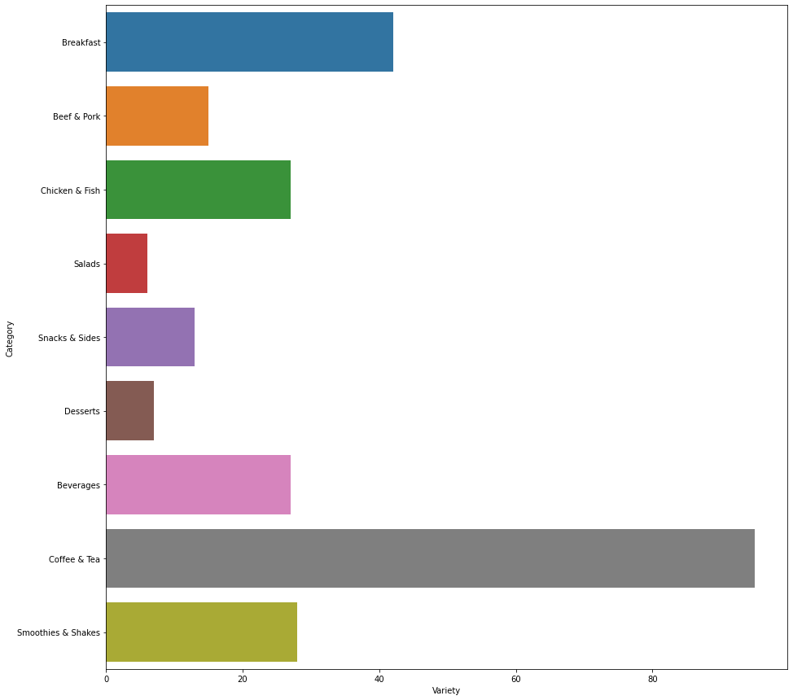

```python
plt.figure(figsize=(15,15))
sns.barplot(y='Category',x='Variety',data=df2)
```

```python
df2
```

|  | Category | Variety |
| --- | --- | --- |
| 0 | Breakfast | 42 |
| 1 | Beef & Pork | 15 |
| 2 | Chicken & Fish | 27 |
| 3 | Salads | 6 |
| 4 | Snacks & Sides | 13 |
| 5 | Desserts | 7 |
| 6 | Beverages | 27 |
| 7 | Coffee & Tea | 95 |
| 8 | Smoothies & Shakes | 28 |

[output not shown]

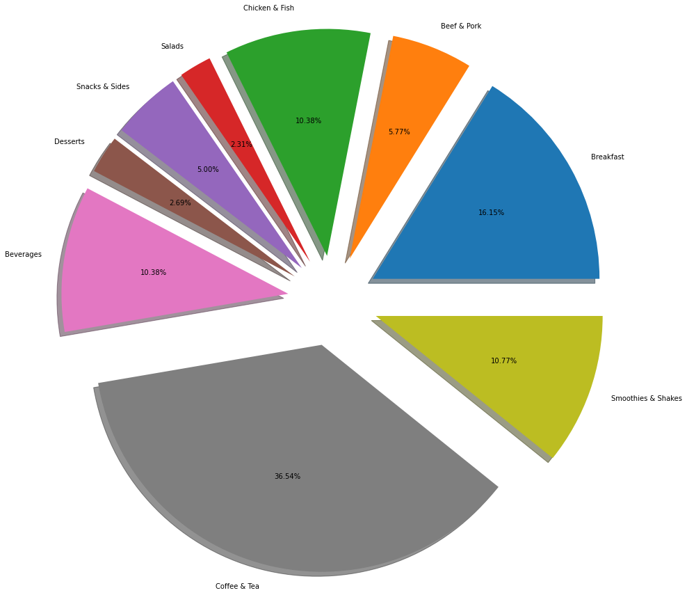

```python
plt.figure(figsize=(15,15))
plt.pie("Variety",labels="Category",data=df2,shadow=True,explode=(0.2,0.2,0.2,0.2,0.2,0.2,0.2,0.2,0.2),autopct='%1.2f%%')
```

```python
df2
```

|  | Category | Variety |
| --- | --- | --- |
| 0 | Breakfast | 42 |
| 1 | Beef & Pork | 15 |
| 2 | Chicken & Fish | 27 |
| 3 | Salads | 6 |
| 4 | Snacks & Sides | 13 |
| 5 | Desserts | 7 |
| 6 | Beverages | 27 |
| 7 | Coffee & Tea | 95 |
| 8 | Smoothies & Shakes | 28 |

As seen above I created a list of the unique values of category and via for loop we obtained the number of items in each category and then made a graphical representation of all the varieties. From the above visualizations, it can be inferred that **Coffee & Tea have the highest number of varieties** with 95 and **salads has the least** with 6. In terms of percentage ,**Coffee comprises of 36.54 %** of the number of Varieties and **salads with 2.31%**

# Which all variables have an outlier?

[output not shown]

[output cut: 13 more lines]

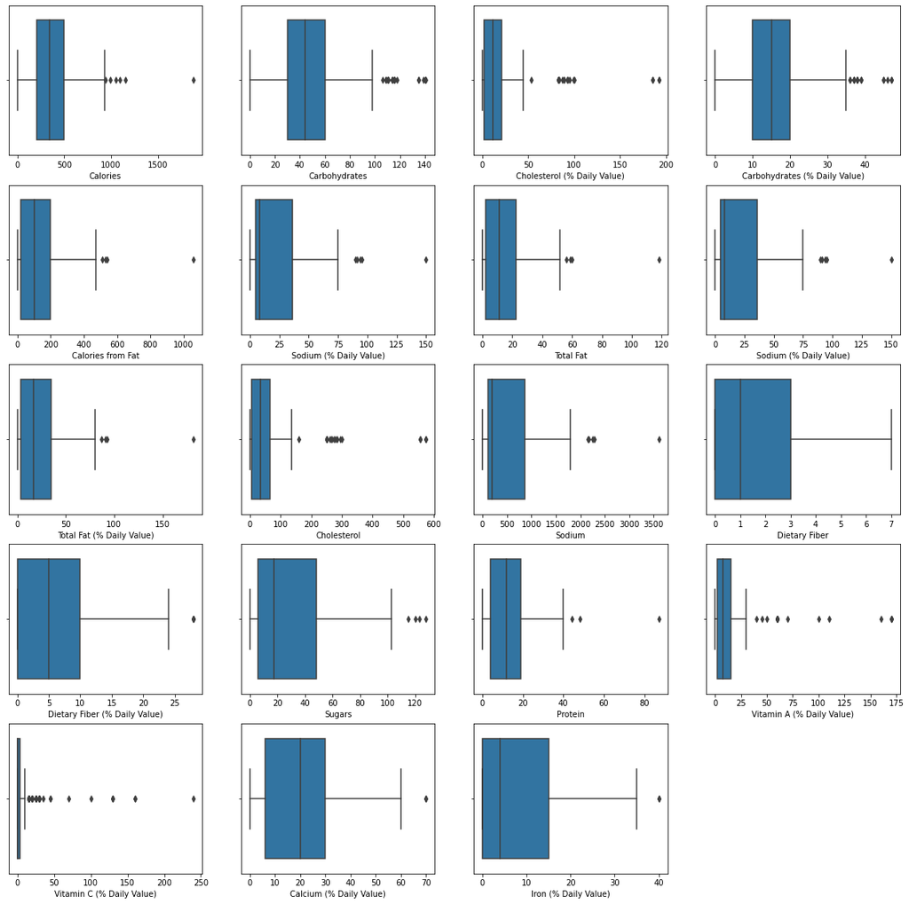

```python
plt.figure(figsize=(20,20))
ax1 = plt.subplot2grid((5,4), (0,0))
sns.boxplot(df.Calories)
ax2 = plt.subplot2grid((5,4), (1,0))
sns.boxplot(df["Calories from Fat"])
ax3 = plt.subplot2grid((5,4), (1, 2))
sns.boxplot(df["Total Fat"])
ax4 = plt.subplot2grid((5,4),(2, 0))
sns.boxplot(df["Total Fat (% Daily Value)"])
ax5 = plt.subplot2grid((5,4), (2, 1))
sns.boxplot(df.Cholesterol)
ax6=plt.subplot2grid((5,4),(0,2))
sns.boxplot(df["Cholesterol (% Daily Value)"])
ax7=plt.subplot2grid((5,4),(2,2))
sns.boxplot(df.Sodium)
ax8=plt.subplot2grid((5,4),(1,1))
sns.boxplot(df["Sodium (% Daily Value)"])
ax9=plt.subplot2grid((5,4),(0,1))
sns.boxplot(df.Carbohydrates)
ax10=plt.subplot2grid((5,4),(0,3))
sns.boxplot(df["Carbohydrates (% Daily Value)"])
ax11=plt.subplot2grid((5,4),(1,3))
sns.boxplot(df["Sodium (% Daily Value)"])
a12=plt.subplot2grid((5,4),(2,3))
sns.boxplot(df["Dietary Fiber"])
a13=plt.subplot2grid((5,4),(3,0))
sns.boxplot(df["Dietary Fiber (% Daily Value)"])
a14=plt.subplot2grid((5,4),(3,1))
sns.boxplot(df["Sugars"])
a15=plt.subplot2grid((5,4),(3,2))
sns.boxplot(df["Protein"])
a16=plt.subplot2grid((5,4),(3,3))
sns.boxplot(df["Vitamin A (% Daily Value)"])
a17=plt.subplot2grid((5,4),(4,0),rowspan=3)
sns.boxplot(df["Vitamin C (% Daily Value)"])
a18=plt.subplot2grid((5,4),(4,1))
sns.boxplot(df["Calcium (% Daily Value)"])
a19=plt.subplot2grid((5,4),(4,2))
sns.boxplot(df["Iron (% Daily Value)"])
plt.show()
```

# Which variables have the highest correlation? Plot them and find out the value?

```python
c=df.corr()
```

```python
c
```

|  | Calories | Calories from Fat | Total Fat | Total Fat (% Daily Value) | Saturated Fat | Saturated Fat (% Daily Value) | Trans Fat | Cholesterol | Cholesterol (% Daily Value) | Sodium | ... | Carbohydrates | Carbohydrates (% Daily Value) | Dietary Fiber | Dietary Fiber (% Daily Value) | Sugars | Protein | Vitamin A (% Daily Value) | Vitamin C (% Daily Value) | Calcium (% Daily Value) | Iron (% Daily Value) |
| --- | --- | --- | --- | --- | --- | --- | --- | --- | --- | --- | --- | --- | --- | --- | --- | --- | --- | --- | --- | --- | --- |
| Calories | 1.000000 | 0.904588 | 0.904409 | 0.904123 | 0.845564 | 0.847631 | 0.522441 | 0.596399 | 0.595208 | 0.712309 | ... | 0.781539 | 0.781242 | 0.538894 | 0.540014 | 0.259598 | 0.787847 | 0.108844 | -0.068747 | 0.428426 | 0.643552 |
| Calories from Fat | 0.904588 | 1.000000 | 0.999663 | 0.999725 | 0.847008 | 0.849592 | 0.433686 | 0.682161 | 0.681607 | 0.846624 | ... | 0.461672 | 0.461463 | 0.581274 | 0.575621 | -0.115285 | 0.807913 | 0.056731 | -0.087331 | 0.161034 | 0.735894 |
| Total Fat | 0.904409 | 0.999663 | 1.000000 | 0.999765 | 0.846707 | 0.849293 | 0.431453 | 0.680547 | 0.680000 | 0.846158 | ... | 0.461213 | 0.461005 | 0.580837 | 0.575206 | -0.115446 | 0.807773 | 0.054434 | -0.089354 | 0.162860 | 0.734685 |
| Total Fat (% Daily Value) | 0.904123 | 0.999725 | 0.999765 | 1.000000 | 0.847379 | 0.849973 | 0.433016 | 0.680940 | 0.680378 | 0.846728 | ... | 0.460516 | 0.460298 | 0.580592 | 0.575033 | -0.115761 | 0.807922 | 0.054038 | -0.089353 | 0.162031 | 0.735478 |
| Saturated Fat | 0.845564 | 0.847008 | 0.846707 | 0.847379 | 1.000000 | 0.999279 | 0.620611 | 0.631210 | 0.630334 | 0.584075 | ... | 0.591261 | 0.591743 | 0.351818 | 0.347152 | 0.197734 | 0.603028 | 0.064972 | -0.179672 | 0.403311 | 0.578062 |
| Saturated Fat (% Daily Value) | 0.847631 | 0.849592 | 0.849293 | 0.849973 | 0.999279 | 1.000000 | 0.620210 | 0.633603 | 0.632712 | 0.588694 | ... | 0.591322 | 0.591655 | 0.356831 | 0.351797 | 0.195928 | 0.606581 | 0.065376 | -0.178059 | 0.401139 | 0.580488 |
| Trans Fat | 0.522441 | 0.433686 | 0.431453 | 0.433016 | 0.620611 | 0.620210 | 1.000000 | 0.253935 | 0.251502 | 0.187580 | ... | 0.463250 | 0.462891 | 0.054918 | 0.058301 | 0.334756 | 0.388249 | 0.075833 | -0.076612 | 0.385331 | 0.325476 |
| Cholesterol | 0.596399 | 0.682161 | 0.680547 | 0.680940 | 0.631210 | 0.633603 | 0.253935 | 1.000000 | 0.999855 | 0.624362 | ... | 0.270977 | 0.272662 | 0.435575 | 0.440266 | -0.135518 | 0.561561 | 0.080239 | -0.082978 | 0.132077 | 0.655000 |
| Cholesterol (% Daily Value) | 0.595208 | 0.681607 | 0.680000 | 0.680378 | 0.630334 | 0.632712 | 0.251502 | 0.999855 | 1.000000 | 0.623320 | ... | 0.269300 | 0.270992 | 0.434940 | 0.439814 | -0.136459 | 0.560957 | 0.080059 | -0.083315 | 0.132382 | 0.653167 |
| Sodium | 0.712309 | 0.846624 | 0.846158 | 0.846728 | 0.584075 | 0.588694 | 0.187580 | 0.624362 | 0.623320 | 1.000000 | ... | 0.200796 | 0.201032 | 0.694389 | 0.689995 | -0.426536 | 0.869802 | 0.083068 | -0.030769 | -0.024074 | 0.871593 |
| Sodium (% Daily Value) | 0.713415 | 0.847276 | 0.846780 | 0.847368 | 0.585323 | 0.589958 | 0.188339 | 0.624743 | 0.623720 | 0.999929 | ... | 0.202426 | 0.202663 | 0.693913 | 0.689464 | -0.424943 | 0.869870 | 0.083259 | -0.030945 | -0.022145 | 0.870742 |
| Carbohydrates | 0.781539 | 0.461672 | 0.461213 | 0.460516 | 0.591261 | 0.591322 | 0.463250 | 0.270977 | 0.269300 | 0.200796 | ... | 1.000000 | 0.999620 | 0.224577 | 0.228257 | 0.762362 | 0.352122 | 0.083802 | -0.034724 | 0.589699 | 0.210241 |
| Carbohydrates (% Daily Value) | 0.781242 | 0.461463 | 0.461005 | 0.460298 | 0.591743 | 0.591655 | 0.462891 | 0.272662 | 0.270992 | 0.201032 | ... | 0.999620 | 1.000000 | 0.224058 | 0.227285 | 0.762282 | 0.352178 | 0.083376 | -0.035450 | 0.590263 | 0.210643 |
| Dietary Fiber | 0.538894 | 0.581274 | 0.580837 | 0.580592 | 0.351818 | 0.356831 | 0.054918 | 0.435575 | 0.434940 | 0.694389 | ... | 0.224577 | 0.224058 | 1.000000 | 0.986350 | -0.295178 | 0.641345 | 0.340518 | 0.141935 | 0.028711 | 0.740411 |
| Dietary Fiber (% Daily Value) | 0.540014 | 0.575621 | 0.575206 | 0.575033 | 0.347152 | 0.351797 | 0.058301 | 0.440266 | 0.439814 | 0.689995 | ... | 0.228257 | 0.227285 | 0.986350 | 1.000000 | -0.287014 | 0.656648 | 0.361380 | 0.150019 | 0.052359 | 0.737814 |
| Sugars | 0.259598 | -0.115285 | -0.115446 | -0.115761 | 0.197734 | 0.195928 | 0.334756 | -0.135518 | -0.136459 | -0.426536 | ... | 0.762362 | 0.762282 | -0.295178 | -0.287014 | 1.000000 | -0.179940 | 0.048488 | -0.069847 | 0.600093 | -0.364767 |
| Protein | 0.787847 | 0.807913 | 0.807773 | 0.807922 | 0.603028 | 0.606581 | 0.388249 | 0.561561 | 0.560957 | 0.869802 | ... | 0.352122 | 0.352178 | 0.641345 | 0.656648 | -0.179940 | 1.000000 | 0.214098 | -0.045777 | 0.327971 | 0.792719 |
| Vitamin A (% Daily Value) | 0.108844 | 0.056731 | 0.054434 | 0.054038 | 0.064972 | 0.065376 | 0.075833 | 0.080239 | 0.080059 | 0.083068 | ... | 0.083802 | 0.083376 | 0.340518 | 0.361380 | 0.048488 | 0.214098 | 1.000000 | 0.069171 | 0.179190 | 0.137879 |
| Vitamin C (% Daily Value) | -0.068747 | -0.087331 | -0.089354 | -0.089353 | -0.179672 | -0.178059 | -0.076612 | -0.082978 | -0.083315 | -0.030769 | ... | -0.034724 | -0.035450 | 0.141935 | 0.150019 | -0.069847 | -0.045777 | 0.069171 | 1.000000 | -0.215380 | 0.001292 |
| Calcium (% Daily Value) | 0.428426 | 0.161034 | 0.162860 | 0.162031 | 0.403311 | 0.401139 | 0.385331 | 0.132077 | 0.132382 | -0.024074 | ... | 0.589699 | 0.590263 | 0.028711 | 0.052359 | 0.600093 | 0.327971 | 0.179190 | -0.215380 | 1.000000 | 0.034149 |
| Iron (% Daily Value) | 0.643552 | 0.735894 | 0.734685 | 0.735478 | 0.578062 | 0.580488 | 0.325476 | 0.655000 | 0.653167 | 0.871593 | ... | 0.210241 | 0.210643 | 0.740411 | 0.737814 | -0.364767 | 0.792719 | 0.137879 | 0.001292 | 0.034149 | 1.000000 |

21 rows × 21 columns

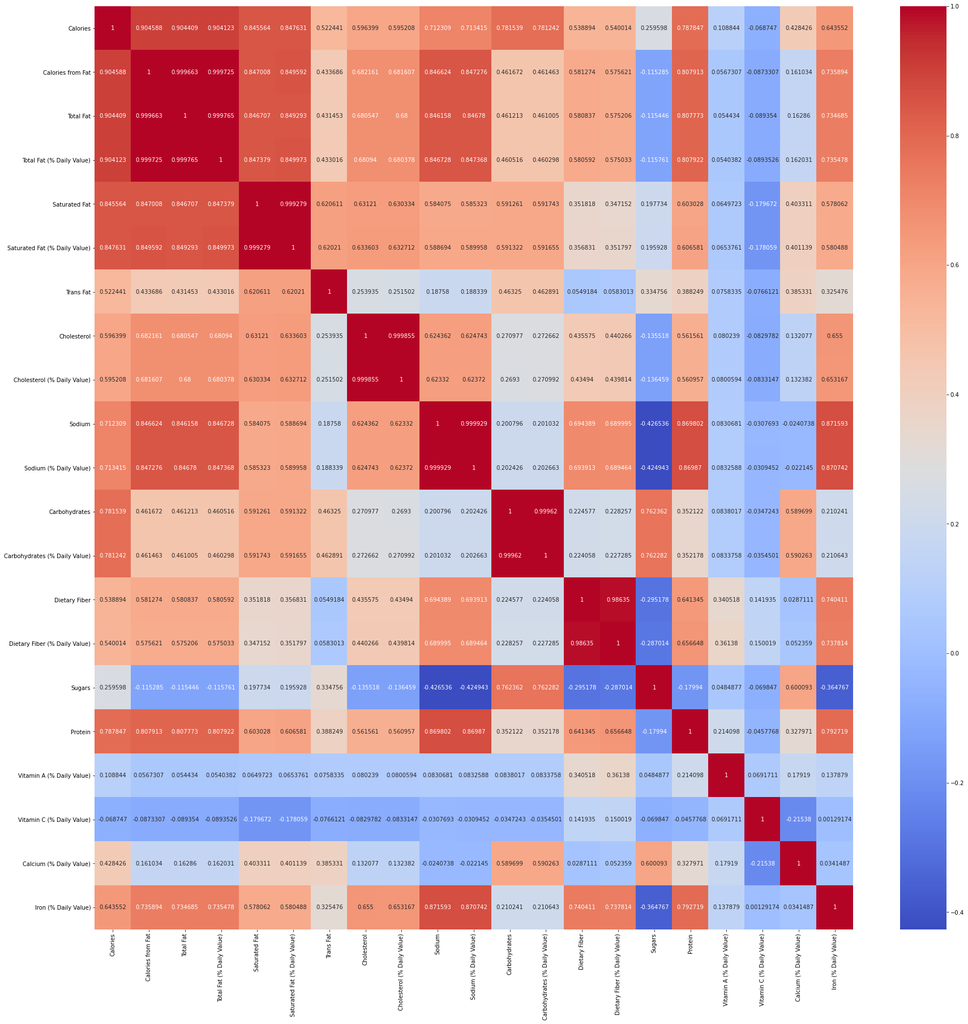

```python
plt.figure(figsize=(30,30))
sns.heatmap(c,annot=True,fmt="g",cmap="coolwarm")
```

As per th color scheme the red shade represents higer correlation from the heatmap displayed, 1) There is a high correlation of Saturated fat and Saturated Fat(% Daily Value) =0.999279

2) A high correlation is observed between Dietary Fiber and Dietary Fiber(% Daily Value)=0.98635

3) A high correlation between Sodium and Sodium(% Daily Value)=0.999929

4) A high Correlation between Carbohydrates and Carbohydrates(% Daily Value)=0.99962

5) A high Correlation between Cholesterol and Cholesterol(% Daily Value)=0.999855

6) A high Correlation between Total Fat(%Daily Value) and Calories from fat and Total Fat=0.999725 and0.999765

**It can be concluded that the variables of the same nutrient have high correlation values**

# Which category contributes to the maximum % of Cholesterol in a diet (% daily value)?

```python
z=df[["Category","Cholesterol (% Daily Value)"]]
```

```python
 z_un=z["Category"].unique()
```

```python
listz=list(z_un)
```

```python
for i in list(z_un):
    print("The sum of % cholestrol in the ",i,"Category is",sum(z[z["Category"]==i]["Cholesterol (% Daily Value)"]))
```

```
The sum of % cholestrol in the  Breakfast Category is 2140
The sum of % cholestrol in the  Beef & Pork Category is 434
The sum of % cholestrol in the  Chicken & Fish Category is 681
The sum of % cholestrol in the  Salads Category is 104
The sum of % cholestrol in the  Snacks & Sides Category is 81
The sum of % cholestrol in the  Desserts Category is 34
The sum of % cholestrol in the  Beverages Category is 5
The sum of % cholestrol in the  Coffee & Tea Category is 891
The sum of % cholestrol in the  Smoothies & Shakes Category is 412
```

```python
data1 = {'Category':['Breakfast', 'Beef & Pork', 'Chicken & Fish', 'Salads',
       'Snacks & Sides', 'Desserts', 'Beverages', 'Coffee & Tea',
       'Smoothies & Shakes'],
        "Cholesterol (% Daily Value) per Category":[2140,434,681,104,81,34,5,891,412]}

# Create DataFrame
df3= pd.DataFrame(data1)

# Print the output.
df3# We will use this dataset to graphically plot the varieties of the Categories
```

|  | Category | Cholesterol (% Daily Value) per Category |
| --- | --- | --- |
| 0 | Breakfast | 2140 |
| 1 | Beef & Pork | 434 |
| 2 | Chicken & Fish | 681 |
| 3 | Salads | 104 |
| 4 | Snacks & Sides | 81 |
| 5 | Desserts | 34 |
| 6 | Beverages | 5 |
| 7 | Coffee & Tea | 891 |
| 8 | Smoothies & Shakes | 412 |

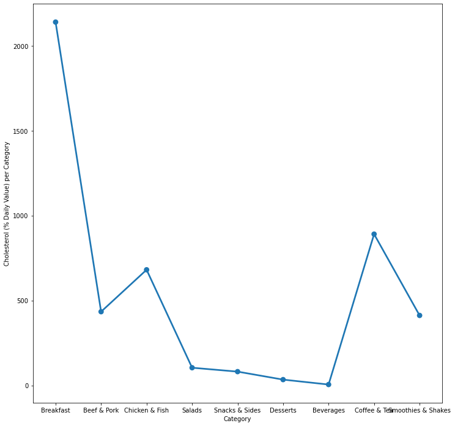

```python
plt.figure(figsize=(12,12))
sns.pointplot(x="Category",y="Cholesterol (% Daily Value) per Category",data=df3)
```

[output not shown]

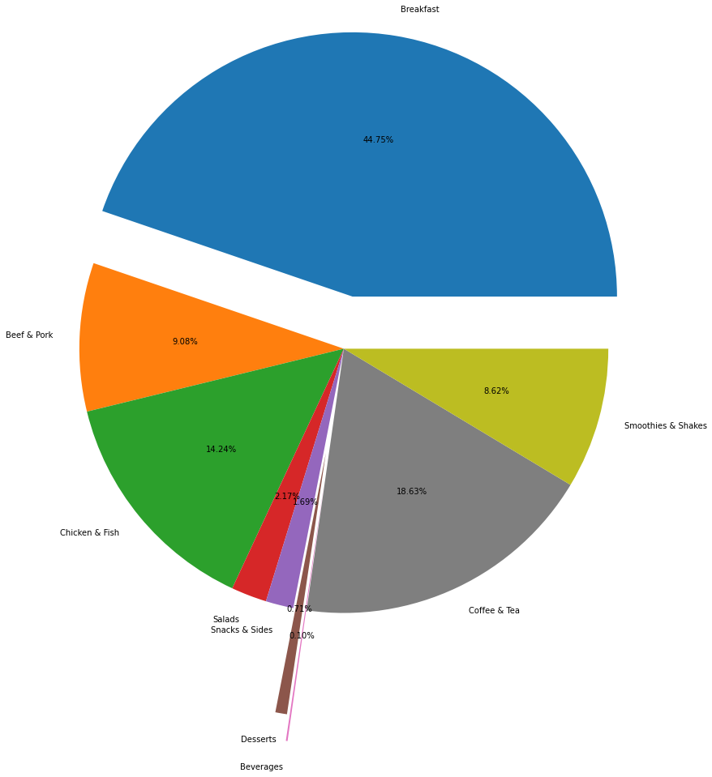

```python
plt.figure(figsize=(15,15))
plt.pie("Cholesterol (% Daily Value) per Category",labels="Category",data=df3,autopct='%1.2f%%',explode=(0.2,0,0,0,0,0.4,0.5,0,0))
```

**It Can be concluded that the breakfast category foods have the highest cholestrol content**

# Which item contributes maximum to the Sodium intake?

```python
y=df[["Item","Sodium"]]
```

```python
y.sort_values(by="Sodium",ascending=False).head(1)
```

|  | Item | Sodium |
| --- | --- | --- |
| 82 | Chicken McNuggets (40 piece) | 3600 |

```python
df["Sodium"].max()
```

```
3600
```

**Chicken Mcnuggets has the largest amount of Sodium**

```python
df.sort_values(by="Sodium(% Daily Value)",ascending=False)
```

[output not shown]

# Which 4 food items contain the most amount of Saturated Fat?

```python
d=df[["Item","Saturated Fat"]]
```

```python
d
```

|  | Item | Saturated Fat |
| --- | --- | --- |
| 0 | Egg McMuffin | 5.0 |
| 1 | Egg White Delight | 3.0 |
| 2 | Sausage McMuffin | 8.0 |
| 3 | Sausage McMuffin with Egg | 10.0 |
| 4 | Sausage McMuffin with Egg Whites | 8.0 |
| ... | ... | ... |
| 255 | McFlurry with Oreo Cookies (Small) | 9.0 |
| 256 | McFlurry with Oreo Cookies (Medium) | 12.0 |
| 257 | McFlurry with Oreo Cookies (Snack) | 6.0 |
| 258 | McFlurry with Reese's Peanut Butter Cups (Medium) | 15.0 |
| 259 | McFlurry with Reese's Peanut Butter Cups (Snack) | 8.0 |

260 rows × 2 columns

```python
d["Saturated Fat"].max()##This is highest value of Saturated Fat of the Items
```

```
20.0
```

```python
d.sort_values(by="Saturated Fat",ascending=False).head(4)
```

|  | Item | Saturated Fat |
| --- | --- | --- |
| 231 | Frappé Chocolate Chip (Large) | 20.0 |
| 82 | Chicken McNuggets (40 piece) | 20.0 |
| 32 | Big Breakfast with Hotcakes (Large Biscuit) | 20.0 |
| 253 | McFlurry with M&M’s Candies (Medium) | 20.0 |

```python
d[d["Saturated Fat"]==20]## It can also alternatively be found like this
```

|  | Item | Saturated Fat |
| --- | --- | --- |
| 32 | Big Breakfast with Hotcakes (Large Biscuit) | 20.0 |
| 82 | Chicken McNuggets (40 piece) | 20.0 |
| 231 | Frappé Chocolate Chip (Large) | 20.0 |
| 253 | McFlurry with M&M’s Candies (Medium) | 20.0 |

**From the analysis done above , it can be concluded that the following have the highest Saturated Fat of 20**

- Big Breakfast with Hotcakes (Large Biscuit)
- Chicken McNuggets (40 piece)
- Frappé Chocolate Chip (Large)
- McFlurry with M&M’s Candies (Medium)